# Wheelseye Online Truck Booking Machine Learning Project

[figure not shown]

## Wheelseye Online Truck Booking Machine Learning Project

**Project By : PRASAD JADHAV**

```python
import pandas as pd
import numpy as np

import matplotlib.pyplot as plt
import seaborn as sns
```

```python
import warnings
warnings.filterwarnings('ignore')
```

```python
df = pd.read_csv('wheelseye_data.csv')
pd.set_option('display.max_columns',20)
print(df.shape)
```

```
(10000, 17)
```

```python
df.head()
```

|  | order_id | customer_id | city_from | city_to | route_distance_km | vehicle_type | material_weight | truck_length_ft | truck_height_ft | business_category | weather_condition | traffic_condition | driver_rating | customer_rating | order_price | delivery_time_hours | is_delayed |
| --- | --- | --- | --- | --- | --- | --- | --- | --- | --- | --- | --- | --- | --- | --- | --- | --- | --- |
| 0 | ORD1000 | CUS9726 | Chennai | Delhi | 1144 | Open Truck | 1.61 Tons | 8 | 6.0 | Transporter | Sunny | Heavy | 3.4 | 3.6 | ₹21282.0 | 20.26 | False |
| 1 | ORD1001 | CUS7464 | Chennai | Pune | 1912 | Open Truck | 1.98 Tons | 20 | 8.0 | Transporter | Cloudy | Moderate | 3.6 | 4.4 | ₹32028.75 | 37.50 | False |
| 2 | ORD1002 | CUS4668 | Kanpur | Indore | 1145 | Open Truck | 7.28 Tons | 7 | 6.0 | Manufacturer | Rainy | Moderate | 3.3 | 4.7 | ₹20158.93 | 16.46 | False |
| 3 | ORD1003 | CUS2876 | Indore | Chennai | 1247 | Open Truck | 8.69 Tons | 19 | 8.0 | Truck Owner | Sunny | Moderate | 4.0 | 3.5 | ₹21944.58 | 25.88 | False |
| 4 | ORD1004 | CUS4137 | Indore | Kanpur | 569 | Small Pickup Truck | 7.6 Tons | 14 | 6.0 | Transporter | Sunny | Moderate | 4.6 | 4.6 | ₹14546.95 | 11.22 | False |

```python
df.tail()
```

|  | order_id | customer_id | city_from | city_to | route_distance_km | vehicle_type | material_weight | truck_length_ft | truck_height_ft | business_category | weather_condition | traffic_condition | driver_rating | customer_rating | order_price | delivery_time_hours | is_delayed |
| --- | --- | --- | --- | --- | --- | --- | --- | --- | --- | --- | --- | --- | --- | --- | --- | --- | --- |
| 9995 | ORD10995 | CUS9223 | Chennai | Ludhiana | 643 | Container | 9.29 Tons | 20 | 8.0 | Individual | Rainy | Moderate | 4.0 | 3.2 | ₹15900.19 | 10.85 | False |
| 9996 | ORD10996 | CUS6562 | Ludhiana | Pune | 917 | Small Pickup Truck | 2.71 Tons | 8 | 6.0 | Truck Owner | Rainy | Light | 3.3 | 4.5 | ₹17555.62 | 22.82 | True |
| 9997 | ORD10997 | CUS3532 | Pune | Delhi | 1687 | Container | 9.76 Tons | 14 | 6.0 | Manufacturer | Cloudy | Moderate | 4.3 | 4.7 | ₹30136.03 | 36.42 | False |
| 9998 | ORD10998 | CUS3105 | Chennai | Indore | 484 | Open Truck | 3.93 Tons | 17 | 6.0 | Manufacturer | Sunny | Heavy | 4.9 | 3.1 | ₹12505.97 | 10.73 | True |
| 9999 | ORD10999 | CUS2121 | Pune | Ahmedabad | 1018 | Small Pickup Truck | 5.72 Tons | 7 | 6.0 | Truck Owner | Cloudy | Light | 4.2 | 5.0 | ₹18041.51 | 17.26 | False |

### Dataset Overview

- order_id: Unique identifier for each transport order (e.g., ORD12345)
- customer_id: Unique identifier for each customer (e.g., CUS5678)
- city_from: Starting city (e.g., Delhi, Mumbai)
- city_to: Destination city (e.g., Kanpur, Chennai)
- route_distance_km: The total distance in kilometers between the start and destination city
- vehicle_type: Type of vehicle used for transport (Open Truck, Container, Small Pickup Truck)
- material_weight: Weight of the material being transported (in Tons or Kg)
- truck_length_ft: Length of the truck (7, 8, 14, 17, 19, 20, 22 ft)
- truck_height_ft: Height of the truck (6.0 ft for smaller trucks, 8.0 ft for larger trucks)
- business_category: Category of the customer (Manufacturer, Transporter, Truck Owner, Individual, Other)
- weather_condition: Weather conditions during the transport (e.g., Sunny, Rainy, Cloudy)
- traffic_condition: Traffic conditions on the route (e.g., Light, Moderate, Heavy)
- driver_rating: Rating of the driver out of 5 stars (e.g., 4.5)
- customer_rating: Customer’s rating of the service out of 5 stars (e.g., 4.8)
- order_price: Price of the transport service (to be fetched based on route, weight, vehicle type, etc.)
- delivery_time_hours: The time taken for the transport service in hours
- is_delayed: Boolean indicating if the delivery was delayed (True or False)

### Data Exploration

```python
df.info()
```

```
<class 'pandas.core.frame.DataFrame'>
RangeIndex: 10000 entries, 0 to 9999
Data columns (total 17 columns):
 #   Column               Non-Null Count  Dtype
---  ------               --------------  -----
 0   order_id             10000 non-null  object
 1   customer_id          10000 non-null  object
 2   city_from            10000 non-null  object
 3   city_to              10000 non-null  object
 4   route_distance_km    10000 non-null  int64
 5   vehicle_type         10000 non-null  object
 6   material_weight      10000 non-null  object
 7   truck_length_ft      10000 non-null  int64
 8   truck_height_ft      10000 non-null  float64
 9   business_category    10000 non-null  object
 10  weather_condition    10000 non-null  object
 11  traffic_condition    10000 non-null  object
 12  driver_rating        10000 non-null  float64
 13  customer_rating      10000 non-null  float64
 14  order_price          10000 non-null  object
 15  delivery_time_hours  10000 non-null  float64
 16  is_delayed           10000 non-null  bool
dtypes: bool(1), float64(4), int64(2), object(10)
memory usage: 1.2+ MB
```

```python
df.isnull().sum()
```

```
order_id               0
customer_id            0
city_from              0
city_to                0
route_distance_km      0
vehicle_type           0
material_weight        0
truck_length_ft        0
truck_height_ft        0
business_category      0
weather_condition      0
traffic_condition      0
driver_rating          0
customer_rating        0
order_price            0
delivery_time_hours    0
is_delayed             0
dtype: int64
```

```python
df.duplicated().sum()
```

```
np.int64(0)
```

```python
df.describe()
```

|  | route_distance_km | truck_length_ft | truck_height_ft | driver_rating | customer_rating | delivery_time_hours |
| --- | --- | --- | --- | --- | --- | --- |
| count | 10000.000000 | 10000.00000 | 10000.00000 | 10000.000000 | 10000.000000 | 10000.000000 |
| mean | 1048.489900 | 15.33730 | 6.86220 | 4.003230 | 3.998540 | 19.552679 |
| std | 547.719651 | 5.45189 | 0.99051 | 0.576817 | 0.580458 | 10.850474 |
| min | 100.000000 | 7.00000 | 6.00000 | 3.000000 | 3.000000 | 1.450000 |
| 25% | 576.000000 | 8.00000 | 6.00000 | 3.500000 | 3.500000 | 10.360000 |
| 50% | 1048.500000 | 17.00000 | 6.00000 | 4.000000 | 4.000000 | 19.130000 |
| 75% | 1526.000000 | 20.00000 | 8.00000 | 4.500000 | 4.500000 | 27.580000 |
| max | 2000.000000 | 22.00000 | 8.00000 | 5.000000 | 5.000000 | 49.830000 |

```python
df.head()
```

|  | order_id | customer_id | city_from | city_to | route_distance_km | vehicle_type | material_weight | truck_length_ft | truck_height_ft | business_category | weather_condition | traffic_condition | driver_rating | customer_rating | order_price | delivery_time_hours | is_delayed |
| --- | --- | --- | --- | --- | --- | --- | --- | --- | --- | --- | --- | --- | --- | --- | --- | --- | --- |
| 0 | ORD1000 | CUS9726 | Chennai | Delhi | 1144 | Open Truck | 1.61 Tons | 8 | 6.0 | Transporter | Sunny | Heavy | 3.4 | 3.6 | ₹21282.0 | 20.26 | False |
| 1 | ORD1001 | CUS7464 | Chennai | Pune | 1912 | Open Truck | 1.98 Tons | 20 | 8.0 | Transporter | Cloudy | Moderate | 3.6 | 4.4 | ₹32028.75 | 37.50 | False |
| 2 | ORD1002 | CUS4668 | Kanpur | Indore | 1145 | Open Truck | 7.28 Tons | 7 | 6.0 | Manufacturer | Rainy | Moderate | 3.3 | 4.7 | ₹20158.93 | 16.46 | False |
| 3 | ORD1003 | CUS2876 | Indore | Chennai | 1247 | Open Truck | 8.69 Tons | 19 | 8.0 | Truck Owner | Sunny | Moderate | 4.0 | 3.5 | ₹21944.58 | 25.88 | False |
| 4 | ORD1004 | CUS4137 | Indore | Kanpur | 569 | Small Pickup Truck | 7.6 Tons | 14 | 6.0 | Transporter | Sunny | Moderate | 4.6 | 4.6 | ₹14546.95 | 11.22 | False |

Step by setp columns price predict ml problem # city_from city_to, Vehicle Type, Material Weight, Truck Length, Truck Height, Business Category:,

```python
num_cols = [x for x in df.columns if df[x].dtypes != 'float64']

for col in num_cols:
    print(f"Value counts for column '{col}':")
    print(df[col].value_counts())
    print("\n" + "_"*40 + "\n")
```

```
Value counts for column 'order_id':
order_id
ORD1000     1
ORD7670     1
ORD7663     1
ORD7664     1
ORD7665     1
           ..
ORD4333     1
ORD4334     1
ORD4335     1
ORD4336     1
ORD10999    1
Name: count, Length: 10000, dtype: int64

________________________________________

Value counts for column 'customer_id':
customer_id
CUS1076    6
CUS8970    6
CUS3108    6
CUS9981    6
CUS4917    6
          ..
CUS5144    1
CUS1596    1
CUS7660    1
CUS7743    1
CUS6562    1
Name: count, Length: 6033, dtype: int64

________________________________________

Value counts for column 'city_from':
city_from
Kanpur       1153
Indore       1136
Mumbai       1133
Ludhiana     1121
```

[output cut: 118 more lines]

```
₹33208.61    1
₹26283.9     1
₹21896.34    1
₹18041.51    1
Name: count, Length: 9977, dtype: int64

________________________________________

Value counts for column 'is_delayed':
is_delayed
False    5052
True     4948
Name: count, dtype: int64

________________________________________
```

```python
cat_cols = [col for col in df.columns if df[col].dtype == 'object' or df[col].dtype.name == 'category']

for col in cat_cols:
    print(f"Value counts for column '{col}':")
    print(df[col].value_counts())
    print("\n" + "_"*40 + "\n")
```

```
Value counts for column 'order_id':
order_id
ORD1000     1
ORD7670     1
ORD7663     1
ORD7664     1
ORD7665     1
           ..
ORD4333     1
ORD4334     1
ORD4335     1
ORD4336     1
ORD10999    1
Name: count, Length: 10000, dtype: int64

________________________________________

Value counts for column 'customer_id':
customer_id
CUS1076    6
CUS8970    6
CUS3108    6
CUS9981    6
CUS4917    6
          ..
CUS5144    1
CUS1596    1
CUS7660    1
CUS7743    1
CUS6562    1
Name: count, Length: 6033, dtype: int64

________________________________________

Value counts for column 'city_from':
city_from
Kanpur       1153
Indore       1136
Mumbai       1133
Ludhiana     1121
```

[output cut: 80 more lines]

```
order_price
₹21979.46    2
₹23487.09    2
₹21104.62    2
₹13382.77    2
₹29033.66    2
            ..
₹25786.97    1
₹33208.61    1
₹26283.9     1
₹21896.34    1
₹18041.51    1
Name: count, Length: 9977, dtype: int64

________________________________________
```

```python
num_features = df.select_dtypes(include = ['int64', 'float64']).dtypes.index
```

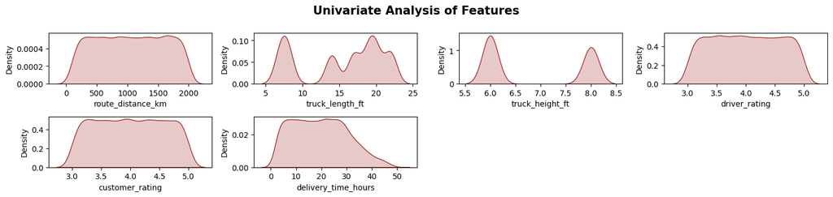

```python
plt.figure(figsize=(15,15))
plt.suptitle('Univariate Analysis of Features',fontweight='bold',fontsize=15,y=1)

for i in range(0,len(num_features)):
    plt.subplot(10,4,i+1)
    sns.kdeplot(x=df[num_features[i]],shade=True,color='brown')
    plt.tight_layout()
```

```python
plt.figure(figsize = (15,15))
plt.suptitle('Univariate Analysis of Features',fontweight='bold',fontsize=20,y=1)

for i in range(0,len(num_features)):
    plt.subplot(10,5,i+1)
    sns.boxplot(data=df,x=num_features[i],color='brown')
    plt.xlabel(num_features[i])
    plt.tight_layout()
```

[output not shown]

```python
cat_features = df.select_dtypes(include='object').dtypes.index
```

```python
plt.figure(figsize=(15,15))
plt.suptitle('Univariate Analysis of Features',fontweight='bold',fontsize=15,y=1)

for i in range(0,len(cat_features)):
    plt.subplot(10,4,i+1)
    sns.countplot(x=df[cat_features[i]],color='brown')
    plt.tight_layout()
```

[output not shown]

```python
# Example Machine Learning Use Cases:
```

```python
# Preprocessing: Convert categorical variables into dummy/one-hot encoding
# df = pd.get_dummies(df, columns=['city_from', 'city_to', 'vehicle_type', 'business_category', 'weather_condition', 'traffic_condition'])
```

```python
# Define mappings for each categorical feature
city_mapping = {city: idx for idx, city in enumerate(df['city_from'].unique())}
vehicle_mapping = {vehicle: idx for idx, vehicle in enumerate(df['vehicle_type'].unique())}
business_mapping = {business: idx for idx, business in enumerate(df['business_category'].unique())}

# Apply the mappings to the columns
df['city_from'] = df['city_from'].map(city_mapping)
df['city_to'] = df['city_to'].map(city_mapping)  # Assuming city_to has similar values to city_from
df['vehicle_type'] = df['vehicle_type'].map(vehicle_mapping)
df['business_category'] = df['business_category'].map(business_mapping)
```

```python
# Remove the word "Tons" from the material_weight column and convert to float
df['material_weight'] = df['material_weight'].str.replace("Tons", "").astype(float)
```

```python
# Define mappings for the categorical features
weather_mapping = {condition: idx for idx, condition in enumerate(df['weather_condition'].unique())}
traffic_mapping = {condition: idx for idx, condition in enumerate(df['traffic_condition'].unique())}
# is_delayed_mapping = {'True': 1, 'False': 0}  # Assuming is_delayed has 'True' and 'False' values

# Apply the mappings to each column
df['weather_condition'] = df['weather_condition'].map(weather_mapping)
df['traffic_condition'] = df['traffic_condition'].map(traffic_mapping)
# df['is_delayed'] = df['is_delayed'].map(is_delayed_mapping)
```

```python
# df['is_delayed'] = df['is_delayed'].map({'False':0, 'True':1}).astype(int)
```

```python
df['is_delayed'] = df['is_delayed'].astype(int)
```

### Price Prediction (Regression)

```python
from sklearn.model_selection import train_test_split
from sklearn.ensemble import RandomForestRegressor
from sklearn.metrics import mean_squared_error
```

```python
price_features = df[['city_from', 'city_to', 'vehicle_type', 'material_weight', 'truck_length_ft', 'truck_height_ft', 'business_category']]
```

```python
# Feature Engineering: Remove unnecessary columns and extract target (price)
df['order_price'] = df['order_price'].replace('[₹,]', '', regex=True).astype(float)
# X = df.drop(['order_id', 'customer_id', 'order_price', 'is_delayed'], axis=1)  # Features
X = price_features
y = df['order_price']  # Target (Price)
```

```python
# Train/Test Split
X_train, X_test, y_train, y_test = train_test_split(X, y, test_size=0.2, random_state=42)
```

```python
# Model Training: Random Forest Regressor
model = RandomForestRegressor(n_estimators=100, random_state=42)
model.fit(X_train, y_train)
```

```
RandomForestRegressor(random_state=42)
```

```python
# Prediction and Evaluation
y_pred = model.predict(X_test)
rmse = np.sqrt(mean_squared_error(y_test, y_pred))
print(f"Price Prediction RMSE: {rmse}")
```

```
Price Prediction RMSE: 8673.3491955699
```

### Delivery Time Estimation (Regression)

```python
from sklearn.tree import DecisionTreeRegressor
```

```python
# Preprocessing: Use the same df but now we focus on predicting delivery time
X = df.drop(['order_id', 'customer_id', 'delivery_time_hours', 'is_delayed'], axis=1)  # Features
y = df['delivery_time_hours']  # Target (Delivery Time)
```

```python
# Train/Test Split
X_train, X_test, y_train, y_test = train_test_split(X, y, test_size=0.2, random_state=42)
```

```python
# Model Training: Random Forest Regressor for Delivery Time
model = DecisionTreeRegressor(random_state=42)
model.fit(X_train, y_train)
```

```
DecisionTreeRegressor(random_state=42)
```

```python
# Prediction and Evaluation
y_pred = model.predict(X_test)
rmse = np.sqrt(mean_squared_error(y_test, y_pred))
print(f"Delivery Time Estimation RMSE: {rmse}")
```

```
Delivery Time Estimation RMSE: 5.053821865677499
```

## Customer Satisfaction Analysis (Regression/Classification)

```python
from sklearn.linear_model import LinearRegression
```

```python
# Regression (Predict Customer Rating)
```

```python
# Preprocessing: Use the same df but now focus on predicting customer rating
X = df.drop(['order_id', 'customer_id', 'customer_rating', 'is_delayed'], axis=1)  # Features
y = df['customer_rating']  # Target (Customer Rating)
```

```python
# Train/Test Split
X_train, X_test, y_train, y_test = train_test_split(X, y, test_size=0.2, random_state=42)
```

```python
# Model Training: Random Forest Regressor for Customer Rating
model = LinearRegression()
model.fit(X_train, y_train)
```

```
LinearRegression()
```

```python
# Prediction and Evaluation
y_pred = model.predict(X_test)
rmse = np.sqrt(mean_squared_error(y_test, y_pred))
print(f"Customer Rating Prediction RMSE: {rmse}")
```

```
Customer Rating Prediction RMSE: 0.5816678982940906
```

```python
# Classification (High/Low Satisfaction)
```

```python
from sklearn.linear_model import LogisticRegression
from sklearn.metrics import accuracy_score
```

```python
# Create a binary column based on customer rating threshold
df['satisfied'] = df['customer_rating'] >= 4.0  # True for ratings >= 4, False otherwise
```

```python
# Preprocessing: Drop unnecessary columns
X = df.drop(['order_id', 'customer_id', 'customer_rating', 'is_delayed', 'satisfied'], axis=1)  # Features
y = df['satisfied'].astype(int)  # Target (Satisfied/Not Satisfied)
```

```python
# Train/Test Split
X_train, X_test, y_train, y_test = train_test_split(X, y, test_size=0.2, random_state=42)
```

```python
model = LogisticRegression()
model.fit(X_train, y_train)
```

```
LogisticRegression()
```

```python
# Prediction and Evaluation
y_pred = model.predict(X_test)
accuracy = accuracy_score(y_test, y_pred)
print(f"Customer Satisfaction Classification Accuracy: {accuracy}")
```

```
Customer Satisfaction Classification Accuracy: 0.5155
```

## Delay Prediction (Classification)

```python
from sklearn.ensemble import RandomForestClassifier
```

```python
# Preprocessing: Predict delay status (is_delayed) as binary classification
X = df.drop(['order_id', 'customer_id', 'is_delayed'], axis=1)  # Features
y = df['is_delayed'].astype(int)  # Target (0: On-time, 1: Delayed)
```

```python
# Train/Test Split
X_train, X_test, y_train, y_test = train_test_split(X, y, test_size=0.2, random_state=42)
```

```python
# Model Training: Random Forest Classifier for Delay Prediction
model = RandomForestClassifier(n_estimators=100, random_state=42)
model.fit(X_train, y_train)
```

```
RandomForestClassifier(random_state=42)
```

```python
# Prediction and Evaluation
y_pred = model.predict(X_test)
accuracy = accuracy_score(y_test, y_pred)
print(f"Delay Prediction Accuracy: {accuracy}")
```

```
Delay Prediction Accuracy: 0.504
```

```python
df.head()
```

|  | order_id | customer_id | city_from | city_to | route_distance_km | vehicle_type | material_weight | truck_length_ft | truck_height_ft | business_category | weather_condition | traffic_condition | driver_rating | customer_rating | order_price | delivery_time_hours | is_delayed | satisfied |
| --- | --- | --- | --- | --- | --- | --- | --- | --- | --- | --- | --- | --- | --- | --- | --- | --- | --- | --- |
| 0 | ORD1000 | CUS9726 | 0 | 3 | 1144 | 0 | 1.61 | 8 | 6.0 | 0 | 0 | 0 | 3.4 | 3.6 | 21282.00 | 20.26 | 0 | False |
| 1 | ORD1001 | CUS7464 | 0 | 4 | 1912 | 0 | 1.98 | 20 | 8.0 | 0 | 1 | 1 | 3.6 | 4.4 | 32028.75 | 37.50 | 0 | True |
| 2 | ORD1002 | CUS4668 | 1 | 2 | 1145 | 0 | 7.28 | 7 | 6.0 | 1 | 2 | 1 | 3.3 | 4.7 | 20158.93 | 16.46 | 0 | True |
| 3 | ORD1003 | CUS2876 | 2 | 0 | 1247 | 0 | 8.69 | 19 | 8.0 | 2 | 0 | 1 | 4.0 | 3.5 | 21944.58 | 25.88 | 0 | False |
| 4 | ORD1004 | CUS4137 | 2 | 1 | 569 | 1 | 7.60 | 14 | 6.0 | 0 | 0 | 1 | 4.6 | 4.6 | 14546.95 | 11.22 | 0 | True |

```python
from xgboost import XGBRegressor
from sklearn.metrics import mean_squared_error

X = price_features  # `price_features` should be a DataFrame with relevant predictor variables
y = df['order_price']

# Split the data into training and testing sets
X_train, X_test, y_train, y_test = train_test_split(X, y, test_size=0.2, random_state=42)

# Train an XGBRegressor with default hyperparameters
xg_model = XGBRegressor()
xg_model.fit(X_train, y_train)

# Prediction and Evaluation
y_pred = xg_model.predict(X_test)
rmse = np.sqrt(mean_squared_error(y_test, y_pred))
print(f"Price Prediction RMSE: {rmse}")
```

```
Price Prediction RMSE: 8963.408836849994
```

```python
from xgboost import XGBRegressor
from sklearn.metrics import mean_squared_error
from sklearn.model_selection import train_test_split

# Ensure price_features and df['order_price'] are defined
# Example: df['order_price'] = df['order_price'].replace('[₹,]', '', regex=True).astype(float)
# X = price_features

# Define features and target variable
X = price_features  # `price_features` should be a DataFrame with relevant predictor variables
y = df['order_price']

# Split the data into training and testing sets
X_train, X_test, y_train, y_test = train_test_split(X, y, test_size=0.2, random_state=42)

# Train an XGBRegressor with default hyperparameters
model = XGBRegressor()
model.fit(X_train, y_train)

# Evaluate the model on the training set
train_preds = model.predict(X_train)
train_mse = mean_squared_error(y_train, train_preds)
train_rmse = np.sqrt(train_mse)

# Evaluate the model on the testing set
test_preds = model.predict(X_test)
test_mse = mean_squared_error(y_test, test_preds)
test_rmse = np.sqrt(test_mse)

print(f"Training RMSE: {train_rmse:.2f}")
print(f"Testing RMSE: {test_rmse:.2f}")
```

```
Training RMSE: 5779.81
Testing RMSE: 8963.41
```

```python
# XGBoost for Price Prediction (Regression)

import xgboost as xgb
from sklearn.model_selection import GridSearchCV, RandomizedSearchCV
from sklearn.metrics import mean_squared_error
from sklearn.model_selection import train_test_split

# Define features and target variable
X = price_features  # price_features should contain only the predictor variables for the model
y = df['order_price']

# Split data into training and testing sets
X_train, X_test, y_train, y_test = train_test_split(X, y, test_size=0.2, random_state=42)

# Instantiate XGBoost Regressor
xgb_reg = xgb.XGBRegressor(objective='reg:squarederror', random_state=42)

# Define a comprehensive hyperparameter grid for fine-tuning
param_grid = {
    'n_estimators': [100, 300, 500, 700],
    'max_depth': [3, 5, 7, 9],
    'learning_rate': [0.01, 0.05, 0.1, 0.2, 0.3],
    'subsample': [0.6, 0.7, 0.8, 0.9, 1.0],
    'colsample_bytree': [0.5, 0.7, 0.8, 0.9, 1.0],
    'gamma': [0, 0.1, 0.2, 0.3, 0.4],
    'min_child_weight': [1, 3, 5, 7]
}

# Set up RandomizedSearchCV with cross-validation
random_search = RandomizedSearchCV(
    estimator=xgb_reg,
    param_distributions=param_grid,
    n_iter=20,  # Increased for more comprehensive search
    scoring='neg_root_mean_squared_error',
    n_jobs=-1,
    cv=3,
    verbose=2,
    random_state=42
)

# Fit the model to find the best hyperparameters
random_search.fit(X_train, y_train)

# Display the best parameters found
print(f"Best parameters: {random_search.best_params_}")

# Predict on the test set and evaluate performance
y_pred = random_search.best_estimator_.predict(X_test)
rmse = np.sqrt(mean_squared_error(y_test, y_pred))
print(f"XGBoost Price Prediction RMSE: {rmse}")
```

```
Fitting 3 folds for each of 20 candidates, totalling 60 fits
Best parameters: {'subsample': 0.9, 'n_estimators': 100, 'min_child_weight': 3, 'max_depth': 3, 'learning_rate': 0.01, 'gamma': 0, 'colsample_bytree': 0.8}
XGBoost Price Prediction RMSE: 8336.01500656909
```

```python
# XGBoost for Delay Prediction (Classification)

import xgboost as xgb
from sklearn.model_selection import RandomizedSearchCV
from sklearn.metrics import accuracy_score

# Preprocessing for delay classification
X = df.drop(['order_id', 'customer_id', 'is_delayed'], axis=1)
y = df['is_delayed'].astype(int)

# Train/Test Split
X_train, X_test, y_train, y_test = train_test_split(X, y, test_size=0.2, random_state=42)

# Hyperparameter tuning using RandomizedSearchCV with XGBoost
xgb_clf = xgb.XGBClassifier()

# Define the hyperparameters and the ranges for tuning
param_grid = {
    'n_estimators': [100, 200, 300],
    'max_depth': [3, 5, 7],
    'learning_rate': [0.01, 0.1, 0.2],
    'subsample': [0.6, 0.8, 1.0],
    'colsample_bytree': [0.6, 0.8, 1.0]
}

# RandomizedSearchCV
random_search = RandomizedSearchCV(xgb_clf, param_distributions=param_grid, n_iter=10, scoring='accuracy',
                                   n_jobs=-1, cv=3, verbose=2, random_state=42)

# Fit the model
random_search.fit(X_train, y_train)

# Best parameters
print(f"Best parameters: {random_search.best_params_}")

# Evaluate the model on test data
y_pred = random_search.best_estimator_.predict(X_test)
accuracy = accuracy_score(y_test, y_pred)
print(f"XGBoost Delay Prediction Accuracy: {accuracy}")
```

```
Fitting 3 folds for each of 10 candidates, totalling 30 fits
Best parameters: {'subsample': 1.0, 'n_estimators': 300, 'max_depth': 7, 'learning_rate': 0.1, 'colsample_bytree': 1.0}
XGBoost Delay Prediction Accuracy: 0.5085
```

```python
#  LightGBM for Price Prediction (Regression)

import lightgbm as lgb
from sklearn.model_selection import RandomizedSearchCV
from sklearn.metrics import mean_squared_error

# Preprocessing as before
X = price_features  # price_features should contain only the predictor variables for the model
y = df['order_price']

# Train/Test Split
X_train, X_test, y_train, y_test = train_test_split(X, y, test_size=0.2, random_state=42)

# Hyperparameter tuning using RandomizedSearchCV with LightGBM
lgb_reg = lgb.LGBMRegressor()

# Define the hyperparameters and the ranges for tuning
param_grid = {
    'n_estimators': [100, 200, 300],
    'max_depth': [3, 5, 7],
    'learning_rate': [0.01, 0.1, 0.2],
    'num_leaves': [31, 50, 100],
    'subsample': [0.6, 0.8, 1.0],
    'colsample_bytree': [0.6, 0.8, 1.0]
}

# RandomizedSearchCV
random_search = RandomizedSearchCV(lgb_reg, param_distributions=param_grid, n_iter=10, scoring='neg_root_mean_squared_error',
                                   n_jobs=-1, cv=3, verbose=2, random_state=42)

# Fit the model
random_search.fit(X_train, y_train)

# Best parameters
print(f"Best parameters: {random_search.best_params_}")

# Evaluate the model on test data
y_pred = random_search.best_estimator_.predict(X_test)
rmse = np.sqrt(mean_squared_error(y_test, y_pred))
print(f"LightGBM Price Prediction RMSE: {rmse}")
```

[output not shown]

[output cut: 41 more lines]

[output not shown]

```python
from catboost import CatBoostRegressor
from sklearn.model_selection import RandomizedSearchCV
from sklearn.metrics import mean_squared_error

# Preprocessing as before
X = price_features  # price_features should contain only the predictor variables for the model
y = df['order_price']

# Train/Test Split
X_train, X_test, y_train, y_test = train_test_split(X, y, test_size=0.2, random_state=42)

# Hyperparameter tuning using RandomizedSearchCV with CatBoostRegressor
cat_reg = CatBoostRegressor(verbose=0)

# Define the hyperparameters and the ranges for tuning
param_grid = {
    'iterations': [100, 200, 300],
    'depth': [4, 6, 8],
    'learning_rate': [0.01, 0.05, 0.1, 0.2],
    'l2_leaf_reg': [3, 5, 7],
    'bagging_temperature': [0, 1, 2],  # Specific for regression to control overfitting
    'random_strength': [1, 2, 5]       # Controls the amount of randomness in the trees
}

# RandomizedSearchCV
random_search = RandomizedSearchCV(cat_reg, param_distributions=param_grid, n_iter=10, scoring='neg_mean_squared_error',
                                   n_jobs=-1, cv=3, verbose=2, random_state=42)

# Fit the model
random_search.fit(X_train, y_train)

# Best parameters
print(f"Best parameters: {random_search.best_params_}")

# Evaluate the model on test data
y_pred = random_search.best_estimator_.predict(X_test)
rmse = np.sqrt(mean_squared_error(y_test, y_pred))
print(f"CatBoost Delay Prediction RMSE: {rmse}")
```

[output not shown]

```python
# CatBoost for Delay Prediction (Classification)

from catboost import CatBoostClassifier
from sklearn.model_selection import RandomizedSearchCV
from sklearn.metrics import accuracy_score

# Preprocessing for CatBoost (no need to one-hot encode)
X = df.drop(['order_id', 'customer_id', 'is_delayed'], axis=1)
y = df['is_delayed'].astype(int)

# Train/Test Split
X_train, X_test, y_train, y_test = train_test_split(X, y, test_size=0.2, random_state=42)

# Hyperparameter tuning using RandomizedSearchCV with CatBoost
cat_clf = CatBoostClassifier(verbose=0)

# Define the hyperparameters and the ranges for tuning
param_grid = {
    'iterations': [100, 200, 300],
    'depth': [4, 6, 8],
    'learning_rate': [0.01, 0.1, 0.2],
    'l2_leaf_reg': [3, 5, 7]
}

# RandomizedSearchCV
random_search = RandomizedSearchCV(cat_clf, param_distributions=param_grid, n_iter=10, scoring='accuracy',
                                   n_jobs=-1, cv=3, verbose=2, random_state=42)

# Fit the model
random_search.fit(X_train, y_train)

# Best parameters
print(f"Best parameters: {random_search.best_params_}")

# Evaluate the model on test data
y_pred = random_search.best_estimator_.predict(X_test)
accuracy = accuracy_score(y_test, y_pred)
print(f"CatBoost Delay Prediction Accuracy: {accuracy}")
```

[output not shown]

```python
# Cross-validation

from sklearn.model_selection import cross_val_score

# Use cross-validation to evaluate the model
xgb_best = random_search.best_estimator_
scores = cross_val_score(xgb_best, X_train, y_train, cv=5, scoring='neg_root_mean_squared_error')
print(f"Cross-Validation RMSE: {-scores.mean():.4f}")
```

[output not shown]

[output cut: 108 more lines]

[output not shown]

[output not shown]

[output cut: 55 more lines]

[output not shown]

[output not shown]

[output cut: 100 more lines]

[output not shown]

[output not shown]

[figure not shown]

```python
# Feature Importance Analysis
# Get feature importances
importance = random_search.best_estimator_.feature_importances_

# Plot feature importance
plt.figure(figsize=(10, 8))
plt.barh(X_train.columns, importance)
plt.xlabel('Feature Importance')
plt.ylabel('Features')
plt.title('Feature Importance for XGBoost Model')
plt.show()
```

```python
# Ensemble Methods

from sklearn.ensemble import StackingRegressor
from sklearn.linear_model import LinearRegression

# Define base models
estimators = [
    ('xgb', xgb.XGBRegressor(**random_search.best_params_)),
    ('lgb', lgb.LGBMRegressor(**random_search.best_params_)),
#    ('cat', CatBoostRegressor(verbose=0))
]

# Stacking regressor with Linear Regression as the final estimator
stacking_reg = StackingRegressor(estimators=estimators, final_estimator=LinearRegression())

# Fit the stacking model
stacking_reg.fit(X_train, y_train)

# Predict and evaluate
y_pred_stack = stacking_reg.predict(X_test)
stack_rmse = np.sqrt(mean_squared_error(y_test, y_pred_stack))
print(f"Stacking RMSE: {stack_rmse:.4f}")
```

[output not shown]

[output cut: 103 more lines]

[output not shown]

[output not shown]

[output cut: 151 more lines]

[output not shown]

[output not shown]

[output cut: 100 more lines]

[output not shown]

[output not shown]

```python
# Final Model Training

# Train the best model on the entire training set
xgb_best.fit(X_train, y_train)

# Make predictions on the test set
y_final_pred = xgb_best.predict(X_test)

# Evaluate the final model
final_rmse = np.sqrt(mean_squared_error(y_test, y_final_pred))
print(f"Final Model RMSE: {final_rmse:.4f}")
```

[output not shown]

[output cut: 38 more lines]

[output not shown]

```python
# Model Deployment

import joblib

# Save the model to disk
joblib.dump(xgb_best, 'final_model_xgboost.pkl')

# Load the model (for later use)
loaded_model = joblib.load('final_model_xgboost.pkl')

# Make predictions with the loaded model
y_loaded_pred = loaded_model.predict(X_test)
```

```python
# Deploy the Model Using Flask (Example)

from flask import Flask, request, jsonify
import joblib
import pandas as pd

app = Flask(__name__)

# Load the model
model = joblib.load('final_model_xgboost.pkl')

@app.route('/predict', methods=['POST'])
def predict():
    data = request.get_json()  # Get data from request
    df = pd.DataFrame(data)  # Convert to DataFrame
    prediction = model.predict(df)  # Make prediction
    return jsonify({'prediction': list(prediction)})

if __name__ == '__main__':
    app.run(debug=True)
```

```
 * Serving Flask app '__main__'
 * Debug mode: on
```

```
WARNING: This is a development server. Do not use it in a production deployment. Use a production WSGI server instead.
 * Running on http://127.0.0.1:5000
Press CTRL+C to quit
 * Restarting with watchdog (windowsapi)
```

```
An exception has occurred, use %tb to see the full traceback.

SystemExit: 1
```

```python
# Flask Deployment

from flask import Flask, request, jsonify
import joblib
import pandas as pd

app = Flask(__name__)

# Load the trained model
try:
    model = joblib.load('final_model_xgboost.pkl')
except Exception as e:
    print(f"Error loading model: {str(e)}")

@app.route('/predict', methods=['POST'])
def predict():
    try:
        # Get the JSON data from the POST request
        data = request.get_json()

        # Convert the JSON data into a Pandas DataFrame
        df = pd.DataFrame([data])

        # Ensure the data structure is correct before making predictions
        if df.empty:
            return jsonify({"error": "Empty input data"})

        # Make predictions using the model
        prediction = model.predict(df)

        # Return the prediction as a JSON response
        return jsonify({'prediction': prediction.tolist()})

    except ValueError as ve:
        return jsonify({"error": f"Value Error: {str(ve)}"}), 400
    except Exception as e:
        return jsonify({"error": f"An error occurred: {str(e)}"}), 500

if __name__ == '__main__':
    try:
        app.run(debug=True)
    except Exception as e:
        print(f"Error starting the Flask app: {str(e)}")
```

```
 * Serving Flask app '__main__'
 * Debug mode: on
```

```
WARNING: This is a development server. Do not use it in a production deployment. Use a production WSGI server instead.
 * Running on http://127.0.0.1:5000
Press CTRL+C to quit
 * Restarting with watchdog (windowsapi)
```

```
An exception has occurred, use %tb to see the full traceback.

SystemExit: 1
```

```python
# Testing the API with curl:
# curl -X POST http://127.0.0.1:5000/predict -H "Content-Type: application/json" -d '{"city_from": "Delhi", "city_to": "Kanpur", "route_distance_km": 500, "vehicle_type": "Open Truck", "material_weight": "1.5 Tons", "truck_length_ft": 14, "truck_height_ft": 6.0, "business_category": "Manufacturer", "weather_condition": "Sunny", "traffic_condition": "Moderate", "driver_rating": 4.5, "customer_rating": 4.8}'
```

```python
#  Streamlit Deployment

import streamlit as st
import joblib
import pandas as pd

# Load the trained model
try:
    model = joblib.load('final_model_xgboost.pkl')
except Exception as e:
    st.error(f"Error loading model: {str(e)}")

# Define the Streamlit app
def predict():
    st.title("Truck Delivery Prediction App")

    # Input fields for the model
    city_from = st.selectbox('City From', ['Delhi', 'Kanpur', 'Mumbai', 'Chennai'])
    city_to = st.selectbox('City To', ['Delhi', 'Kanpur', 'Mumbai', 'Chennai'])
    route_distance_km = st.number_input('Route Distance (km)', min_value=1, value=500)
    vehicle_type = st.selectbox('Vehicle Type', ['Open Truck', 'Container', 'Small Pickup Truck'])
    material_weight = st.number_input('Material Weight (Tons)', min_value=0.1, value=1.5)
    truck_length_ft = st.selectbox('Truck Length (ft)', [7, 8, 14, 17, 19, 20, 22])
    truck_height_ft = st.selectbox('Truck Height (ft)', [6.0, 8.0])
    business_category = st.selectbox('Business Category', ['Manufacturer', 'Transporter', 'Truck Owner', 'Individual', 'Other'])
    weather_condition = st.selectbox('Weather Condition', ['Sunny', 'Rainy', 'Cloudy'])
    traffic_condition = st.selectbox('Traffic Condition', ['Light', 'Moderate', 'Heavy'])
    driver_rating = st.slider('Driver Rating', 1.0, 5.0, 4.5)
    customer_rating = st.slider('Customer Rating', 1.0, 5.0, 4.8)

    # Create a button for prediction
    if st.button('Predict'):
        try:
            # Create a DataFrame with the input values
            input_data = pd.DataFrame({
                'city_from': [city_from],
                'city_to': [city_to],
                'route_distance_km': [route_distance_km],
                'vehicle_type': [vehicle_type],
                'material_weight': [material_weight],
                'truck_length_ft': [truck_length_ft],
                'truck_height_ft': [truck_height_ft],
                'business_category': [business_category],
                'weather_condition': [weather_condition],
                'traffic_condition': [traffic_condition],
                'driver_rating': [driver_rating],
                'customer_rating': [customer_rating]
            })

            # Make predictions using the loaded model
            prediction = model.predict(input_data)
            st.success(f"Predicted Price: ₹{prediction[0]:.2f}")

        except ValueError as ve:
            st.error(f"Value Error: {str(ve)}")
        except Exception as e:
            st.error(f"An error occurred: {str(e)}")

# Run the Streamlit app
if __name__ == '__main__':
    predict()
```

```
2024-11-01 10:22:03.385
  Warning: to view this Streamlit app on a browser, run it with the following
  command:

    streamlit run C:\Users\prasad jadhav\AppData\Local\Programs\Python\Python310\lib\site-packages\ipykernel_launcher.py [ARGUMENTS]
```

```python
# streamlit run your_app_name.py
```

```python
# Code to Optimize Multiple Models Using Optuna:

import optuna
import pandas as pd
import numpy as np
from sklearn.model_selection import train_test_split, cross_val_score
from sklearn.metrics import mean_squared_error, accuracy_score
from sklearn.linear_model import Ridge
from sklearn.tree import DecisionTreeRegressor
from sklearn.ensemble import RandomForestRegressor, GradientBoostingRegressor
from xgboost import XGBRegressor
from sklearn.neural_network import MLPRegressor
from sklearn.preprocessing import StandardScaler #, LabelEncoder

# Load the dataset
# df = pd.read_csv('truck_booking_dataset.csv')

# Define the target and features
X = price_features  # price_features should contain only the predictor variables for the model
y = df['order_price']

# Label encoding for categorical features
# categorical_cols = ['city_from', 'city_to', 'vehicle_type', 'business_category', 'weather_condition', 'traffic_condition']
# for col in categorical_cols:
#     le = LabelEncoder()
#     X[col] = le.fit_transform(X[col])

# Train-test split
X_train, X_test, y_train, y_test = train_test_split(X, y, test_size=0.2, random_state=42)

# Standardize the data for models that require scaling
scaler = StandardScaler()
X_train_scaled = scaler.fit_transform(X_train)
X_test_scaled = scaler.transform(X_test)

# Optuna objective function to optimize different models
def objective(trial):
    # Choose the model type
    model_type = trial.suggest_categorical("model", ["ridge", "decision_tree", "random_forest", "gradient_boosting", "xgboost", "mlp"])

    if model_type == "ridge":
        # Ridge Regression
        alpha = trial.suggest_float("alpha", 1e-3, 10.0, log=True)
        model = Ridge(alpha=alpha)

    elif model_type == "decision_tree":
        # Decision Tree Regressor
        max_depth = trial.suggest_int("max_depth", 2, 32)
        min_samples_split = trial.suggest_int("min_samples_split", 2, 20)
        model = DecisionTreeRegressor(max_depth=max_depth, min_samples_split=min_samples_split)

    elif model_type == "random_forest":
        # Random Forest Regressor
        n_estimators = trial.suggest_int("n_estimators", 100, 1000)
        max_depth = trial.suggest_int("max_depth", 2, 32)
        model = RandomForestRegressor(n_estimators=n_estimators, max_depth=max_depth)

    elif model_type == "gradient_boosting":
        # Gradient Boosting Regressor
        learning_rate = trial.suggest_float("learning_rate", 1e-3, 0.1, log=True)
        n_estimators = trial.suggest_int("n_estimators", 100, 1000)
        max_depth = trial.suggest_int("max_depth", 2, 32)
        model = GradientBoostingRegressor(learning_rate=learning_rate, n_estimators=n_estimators, max_depth=max_depth)

    elif model_type == "xgboost":
        # XGBoost Regressor
        learning_rate = trial.suggest_float("learning_rate", 1e-3, 0.1, log=True)
        n_estimators = trial.suggest_int("n_estimators", 100, 1000)
        max_depth = trial.suggest_int("max_depth", 2, 32)
        model = XGBRegressor(learning_rate=learning_rate, n_estimators=n_estimators, max_depth=max_depth)

    elif model_type == "mlp":
        # Neural Network (MLP)
        hidden_layer_sizes = trial.suggest_categorical("hidden_layer_sizes", [(50,50), (100,100), (50,100)])
        activation = trial.suggest_categorical("activation", ["relu", "tanh"])
        learning_rate_init = trial.suggest_float("learning_rate_init", 1e-4, 1e-2, log=True)
        model = MLPRegressor(hidden_layer_sizes=hidden_layer_sizes, activation=activation, learning_rate_init=learning_rate_init)

    # Cross-validation scoring
    score = cross_val_score(model, X_train_scaled, y_train, cv=3, scoring='neg_mean_squared_error').mean()

    return -score

# Create an Optuna study for hyperparameter optimization
study = optuna.create_study(direction='minimize')
study.optimize(objective, n_trials=100)

# Print the best parameters and best model type
print("Best model:", study.best_trial.params)

# Train the best model on the full training set
best_model_params = study.best_trial.params
model_type = best_model_params.pop("model")

if model_type == "ridge":
    model = Ridge(**best_model_params)
elif model_type == "decision_tree":
    model = DecisionTreeRegressor(**best_model_params)
elif model_type == "random_forest":
    model = RandomForestRegressor(**best_model_params)
elif model_type == "gradient_boosting":
    model = GradientBoostingRegressor(**best_model_params)
elif model_type == "xgboost":
    model = XGBRegressor(**best_model_params)
elif model_type == "mlp":
    model = MLPRegressor(**best_model_params)

# Fit the model on the full training set
model.fit(X_train_scaled, y_train)

# Predict on the test set
y_pred = model.predict(X_test_scaled)

# Evaluate the model
mse = mean_squared_error(y_test, y_pred)
print(f"Test MSE: {mse}")
```

[output not shown]

[output cut: 14 more lines]

[output not shown]

[output cut: 14 more lines]

[output not shown]

```
Best model: {'model': 'ridge', 'alpha': 9.993329168835508}
Test MSE: 69594019.82830097
```

```python
import optuna
from sklearn.model_selection import train_test_split, cross_val_score
from sklearn.metrics import mean_squared_error
from sklearn.linear_model import Ridge
from sklearn.tree import DecisionTreeRegressor
from sklearn.ensemble import RandomForestRegressor, GradientBoostingRegressor
from xgboost import XGBRegressor
from sklearn.neural_network import MLPRegressor
from sklearn.preprocessing import StandardScaler
import pickle

# Define the target and features
X = price_features  # price_features should contain only the predictor variables for the model
y = df['order_price']

# Train-test split
X_train, X_test, y_train, y_test = train_test_split(X, y, test_size=0.2, random_state=42)

# Standardize the data for models that require scaling
scaler = StandardScaler()
X_train_scaled = scaler.fit_transform(X_train)
X_test_scaled = scaler.transform(X_test)

# Optuna objective function to optimize different models
def objective(trial):
    # Choose the model type
    model_type = trial.suggest_categorical("model", ["ridge", "decision_tree", "random_forest", "gradient_boosting", "xgboost", "mlp"])

    if model_type == "ridge":
        # Ridge Regression
        alpha = trial.suggest_float("alpha", 1e-3, 10.0, log=True)
        model = Ridge(alpha=alpha)

    elif model_type == "decision_tree":
        # Decision Tree Regressor
        max_depth = trial.suggest_int("max_depth", 2, 32)
        min_samples_split = trial.suggest_int("min_samples_split", 2, 20)
        model = DecisionTreeRegressor(max_depth=max_depth, min_samples_split=min_samples_split)

    elif model_type == "random_forest":
        # Random Forest Regressor
        n_estimators = trial.suggest_int("n_estimators", 100, 1000)
        max_depth = trial.suggest_int("max_depth", 2, 32)
        model = RandomForestRegressor(n_estimators=n_estimators, max_depth=max_depth)

    elif model_type == "gradient_boosting":
        # Gradient Boosting Regressor
        learning_rate = trial.suggest_float("learning_rate", 1e-3, 0.1, log=True)
        n_estimators = trial.suggest_int("n_estimators", 100, 1000)
        max_depth = trial.suggest_int("max_depth", 2, 32)
        model = GradientBoostingRegressor(learning_rate=learning_rate, n_estimators=n_estimators, max_depth=max_depth)

    elif model_type == "xgboost":
        # XGBoost Regressor
        learning_rate = trial.suggest_float("learning_rate", 1e-3, 0.1, log=True)
        n_estimators = trial.suggest_int("n_estimators", 100, 1000)
        max_depth = trial.suggest_int("max_depth", 2, 32)
        model = XGBRegressor(learning_rate=learning_rate, n_estimators=n_estimators, max_depth=max_depth)

    elif model_type == "mlp":
        # Neural Network (MLP)
        hidden_layer_sizes = trial.suggest_categorical("hidden_layer_sizes", [(50,50), (100,100), (50,100)])
        activation = trial.suggest_categorical("activation", ["relu", "tanh"])
        learning_rate_init = trial.suggest_float("learning_rate_init", 1e-4, 1e-2, log=True)
        model = MLPRegressor(hidden_layer_sizes=hidden_layer_sizes, activation=activation, learning_rate_init=learning_rate_init)

    # Cross-validation scoring
    score = cross_val_score(model, X_train_scaled, y_train, cv=3, scoring='neg_mean_squared_error').mean()

    return -score

# Create an Optuna study for hyperparameter optimization
study = optuna.create_study(direction='minimize')
study.optimize(objective, n_trials=100)

# Print the best parameters and best model type
print("Best model parameters:", study.best_trial.params)

# Train the best model on the full training set
best_model_params = study.best_trial.params
model_type = best_model_params.pop("model")

# Define the best model using the best parameters
if model_type == "ridge":
    best_model = Ridge(**best_model_params)
elif model_type == "decision_tree":
    best_model = DecisionTreeRegressor(**best_model_params)
elif model_type == "random_forest":
    best_model = RandomForestRegressor(**best_model_params)
elif model_type == "gradient_boosting":
    best_model = GradientBoostingRegressor(**best_model_params)
elif model_type == "xgboost":
    best_model = XGBRegressor(**best_model_params)
elif model_type == "mlp":
    best_model = MLPRegressor(**best_model_params)

# Fit the best model on the full training set
best_model.fit(X_train_scaled, y_train)

# Save the best model as a .pkl file
pickle.dump(best_model, 'best_model.pkl', 'wb')
# print("Best model saved as 'best_model.pkl'")
```

[output not shown]

[output cut: 14 more lines]

[output not shown]

[output cut: 14 more lines]

[output not shown]

```
Best model parameters: {'model': 'ridge', 'alpha': 9.981373794788786}
```

[output not shown]

```python
pickle.dump(best_model,open('base_model.pkl','wb'))
model = pickle.load(open('base_model.pkl','rb'))
```

```python
price_features.head()
```

|  | city_from | city_to | vehicle_type | material_weight | truck_length_ft | truck_height_ft | business_category |
| --- | --- | --- | --- | --- | --- | --- | --- |
| 0 | 0 | 3 | 0 | 1.61 | 8 | 6.0 | 0 |
| 1 | 0 | 4 | 0 | 1.98 | 20 | 8.0 | 0 |
| 2 | 1 | 2 | 0 | 7.28 | 7 | 6.0 | 1 |
| 3 | 2 | 0 | 0 | 8.69 | 19 | 8.0 | 2 |
| 4 | 2 | 1 | 1 | 7.60 | 14 | 6.0 | 0 |

```python
price_features.dtypes
```

```
city_from              int64
city_to                int64
vehicle_type           int64
material_weight      float64
truck_length_ft        int64
truck_height_ft      float64
business_category      int64
dtype: object
```

```python
price_features.head()
```

|  | city_from | city_to | vehicle_type | material_weight | truck_length_ft | truck_height_ft | business_category |
| --- | --- | --- | --- | --- | --- | --- | --- |
| 0 | 0 | 3 | 0 | 1.61 | 8 | 6.0 | 0 |
| 1 | 0 | 4 | 0 | 1.98 | 20 | 8.0 | 0 |
| 2 | 1 | 2 | 0 | 7.28 | 7 | 6.0 | 1 |
| 3 | 2 | 0 | 0 | 8.69 | 19 | 8.0 | 2 |
| 4 | 2 | 1 | 1 | 7.60 | 14 | 6.0 | 0 |

```python
y.head()
```

```
0    21282.00
1    32028.75
2    20158.93
3    21944.58
4    14546.95
Name: order_price, dtype: float64
```

```python
print('Enter Truck Details')

city_from = int(input('Enter the City From: '))
city_to = int(input('Enter the City To: '))
vehicle_type = int(input('Enter the Vehicle Type: '))
material_weight = float(input('Enter the Material Weight: '))
truck_length_ft = int(input('Enter the Truck Length ft: '))
truck_height_ft = float(input('Enter the Truck Height ft: '))
business_category = int(input('Enter the Business Category: '))

input_point = np.array([[city_from, city_to, vehicle_type, material_weight, truck_length_ft, truck_height_ft, business_category]])

model.predict(input_point)
```

```
Enter Truck Details
Enter the City From: 0
Enter the City To: 3
Enter the Vehicle Type: 0
Enter the Material Weight: 1.61
Enter the Truck Length ft: 8
Enter the Truck Height ft: 6.0
Enter the Business Category: 0
```

```
array([21259.9722974])
```

```python
df.head()
```

|  | order_id | customer_id | city_from | city_to | route_distance_km | vehicle_type | material_weight | truck_length_ft | truck_height_ft | business_category | weather_condition | traffic_condition | driver_rating | customer_rating | order_price | delivery_time_hours | is_delayed | satisfied |
| --- | --- | --- | --- | --- | --- | --- | --- | --- | --- | --- | --- | --- | --- | --- | --- | --- | --- | --- |
| 0 | ORD1000 | CUS9726 | 0 | 3 | 1144 | 0 | 1.61 | 8 | 6.0 | 0 | 0 | 0 | 3.4 | 3.6 | 21282.00 | 20.26 | 0 | False |
| 1 | ORD1001 | CUS7464 | 0 | 4 | 1912 | 0 | 1.98 | 20 | 8.0 | 0 | 1 | 1 | 3.6 | 4.4 | 32028.75 | 37.50 | 0 | True |
| 2 | ORD1002 | CUS4668 | 1 | 2 | 1145 | 0 | 7.28 | 7 | 6.0 | 1 | 2 | 1 | 3.3 | 4.7 | 20158.93 | 16.46 | 0 | True |
| 3 | ORD1003 | CUS2876 | 2 | 0 | 1247 | 0 | 8.69 | 19 | 8.0 | 2 | 0 | 1 | 4.0 | 3.5 | 21944.58 | 25.88 | 0 | False |
| 4 | ORD1004 | CUS4137 | 2 | 1 | 569 | 1 | 7.60 | 14 | 6.0 | 0 | 0 | 1 | 4.6 | 4.6 | 14546.95 | 11.22 | 0 | True |

```python
price_features.head()
```

|  | city_from | city_to | vehicle_type | material_weight | truck_length_ft | truck_height_ft | business_category |
| --- | --- | --- | --- | --- | --- | --- | --- |
| 0 | 0 | 3 | 0 | 1.61 | 8 | 6.0 | 0 |
| 1 | 0 | 4 | 0 | 1.98 | 20 | 8.0 | 0 |
| 2 | 1 | 2 | 0 | 7.28 | 7 | 6.0 | 1 |
| 3 | 2 | 0 | 0 | 8.69 | 19 | 8.0 | 2 |
| 4 | 2 | 1 | 1 | 7.60 | 14 | 6.0 | 0 |

```python
price_features.to_csv('price_features.csv')
```

```python
df_1 = pd.read_csv('wheelseye_data.csv')
pd.set_option('display.max_columns',20)
print(df.shape)
```

```
(10000, 18)
```

```python
df_1.head()
```

|  | order_id | customer_id | city_from | city_to | route_distance_km | vehicle_type | material_weight | truck_length_ft | truck_height_ft | business_category | weather_condition | traffic_condition | driver_rating | customer_rating | order_price | delivery_time_hours | is_delayed |
| --- | --- | --- | --- | --- | --- | --- | --- | --- | --- | --- | --- | --- | --- | --- | --- | --- | --- |
| 0 | ORD1000 | CUS9726 | Chennai | Delhi | 1144 | Open Truck | 1.61 Tons | 8 | 6.0 | Transporter | Sunny | Heavy | 3.4 | 3.6 | ₹21282.0 | 20.26 | False |
| 1 | ORD1001 | CUS7464 | Chennai | Pune | 1912 | Open Truck | 1.98 Tons | 20 | 8.0 | Transporter | Cloudy | Moderate | 3.6 | 4.4 | ₹32028.75 | 37.50 | False |
| 2 | ORD1002 | CUS4668 | Kanpur | Indore | 1145 | Open Truck | 7.28 Tons | 7 | 6.0 | Manufacturer | Rainy | Moderate | 3.3 | 4.7 | ₹20158.93 | 16.46 | False |
| 3 | ORD1003 | CUS2876 | Indore | Chennai | 1247 | Open Truck | 8.69 Tons | 19 | 8.0 | Truck Owner | Sunny | Moderate | 4.0 | 3.5 | ₹21944.58 | 25.88 | False |
| 4 | ORD1004 | CUS4137 | Indore | Kanpur | 569 | Small Pickup Truck | 7.6 Tons | 14 | 6.0 | Transporter | Sunny | Moderate | 4.6 | 4.6 | ₹14546.95 | 11.22 | False |

```python
price_features.columns
```

```
Index(['city_from', 'city_to', 'vehicle_type', 'material_weight',
       'truck_length_ft', 'truck_height_ft', 'business_category'],
      dtype='object')
```

```python
df_v1 = df_1[['city_from', 'city_to', 'vehicle_type', 'material_weight', 'truck_length_ft', 'truck_height_ft', 'business_category']]
```

```python
df_v1.head()
```

|  | city_from | city_to | vehicle_type | material_weight | truck_length_ft | truck_height_ft | business_category |
| --- | --- | --- | --- | --- | --- | --- | --- |
| 0 | Chennai | Delhi | Open Truck | 1.61 Tons | 8 | 6.0 | Transporter |
| 1 | Chennai | Pune | Open Truck | 1.98 Tons | 20 | 8.0 | Transporter |
| 2 | Kanpur | Indore | Open Truck | 7.28 Tons | 7 | 6.0 | Manufacturer |
| 3 | Indore | Chennai | Open Truck | 8.69 Tons | 19 | 8.0 | Truck Owner |
| 4 | Indore | Kanpur | Small Pickup Truck | 7.6 Tons | 14 | 6.0 | Transporter |

```python
price_features.to_csv('encoded_features.csv')
df_v1.to_csv('cc_features.csv')
```

##### Thank You!

```python
# More Advance Working Sonn..!
```

```python
# Notebook Project By : PRASAD JADHAV (ML-ENG)
```

```python
# LinkedIn: linkedin.com/in/prasadmjadhav2 Github: github.com/prasadmjadhav2 Mail: prasadmjadhav6161@gmail.com
```